# MODELOS LINEARES GENERALIZADOS (EST082)

LISTA 2 - Dados contínuos e positivos

Autor

Jaqueline Lamas da Silva

# Exercício 7

**Código**

```r
suppressMessages(vidros <- read_table("dados/lista2/vidros.txt",
    col_names = FALSE, col_types = cols(X2 = col_factor(levels = c("1","2", "3", "4")), X3 = col_factor(levels = c("1", "2")))))
colnames(vidros)<-c("resistencia","voltagem","temperatura")

vidros<-vidros |>
  mutate(voltagem=factor(voltagem, levels = c(1:4),labels = paste0(150+c(1:4)*50,"kV")), temperatura = factor(temperatura, 1:2, labels=c("170°C","180°C")))
```

## Análise Exploratória

**Código**

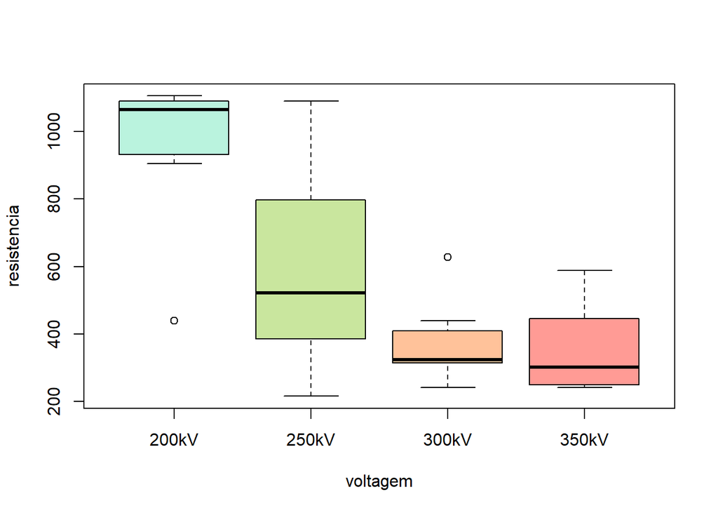

```r
suppressMessages(attach(vidros))
boxplot(resistencia~voltagem, col=cores)
```

Os vidros parecem resistir por mais tempo a voltagens menores.

**Código**

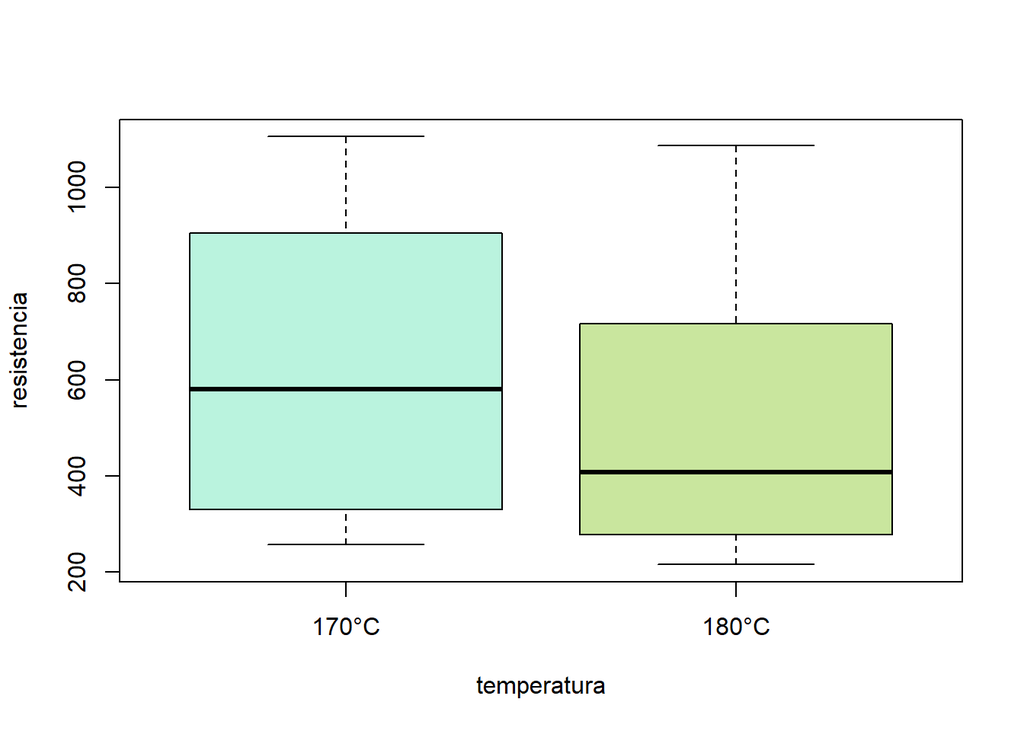

```r
boxplot(resistencia~temperatura, col=cores)
```

A temperatura apresenta uma mediana levemente menor, ou seja, talvez os vidros sejam menos resistentes a temperaturas maiores.

## Seleção do modelo

### Normal

**Código**

```
[1] "Normal-Link(identity)"
```

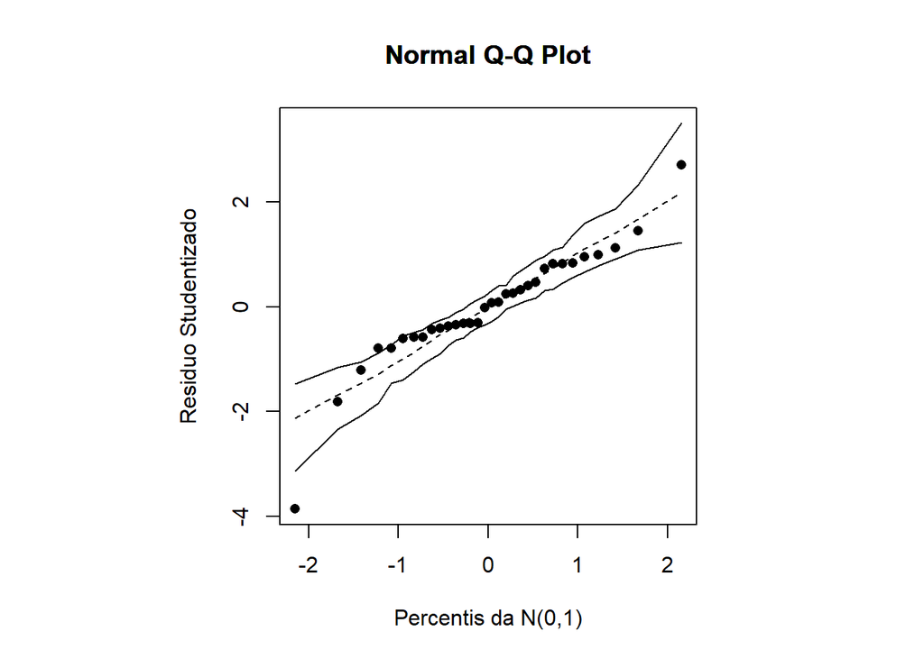

```
[1] "Normal-Link(log)"
[1] "Normal-Link(inverse)"
```

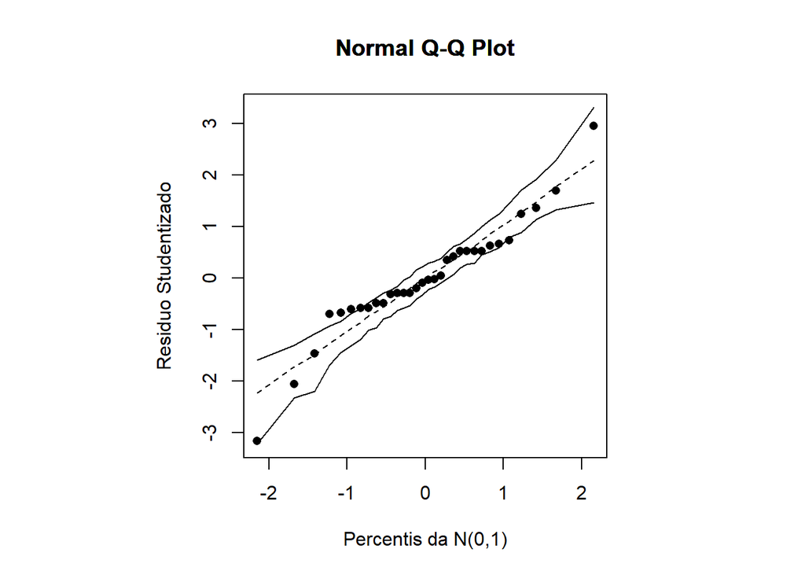

```r
modelo<-resistencia ~ voltagem + temperatura

selecaoModeloNormal<-function(dados, modelo, ligacao)
{
  fit1<-try(switch(ligacao,
                identity = glm(modelo, family=gaussian),
                log = glm(modelo, family=gaussian(link=log)),
                inverse = glm(modelo, family=gaussian(link=inverse)),
                stop("Link não reconhecido")), silent = T)

  aux<-sum(class(fit1) != "try-error")
  if(aux==0)
  {
    fit.model<-0
  }else{
      fit.model<-stepAIC(fit1, trace=0)
  }
  return(fit.model)
}

ResultadosNormal<-function(dados, modelo, ligacao, tipo, alfa=0.05)
{
  n<-nrow(dados)
  familia<-paste0("Normal-Link(",ligacao,")")
  print(familia)
  fits<-selecaoModeloNormal(dados, modelo, ligacao)
  if(is.numeric(fits))
  {
    bic<-"Não Rodou"
    qualidade<-"Não Rodou"
    modelo.s<-"-----"

  }else{
         bic<-as.numeric(round(AIC(fits,k=log(n)),6))
         modelo.s<-deparse(formula(fits))
         teste<-try(envelope(fits,tipo), silent=T)
         aux<-sum(class(teste) != "try-error")
        if(aux==0)
        {
            qualidade<-"Não Rodou"
       }else{
              qualidade<-teste[[1]]
            }
  }
  return(data.frame(Family=familia,
                      QQplot=qualidade,
                      BIC=bic,
                      Modelo=modelo.s))

}

normal<-rbind(
ResultadosNormal(vidros, modelo, ligacao = "identity", tipo ="envel_norm"),
ResultadosNormal(vidros, modelo, ligacao = "log", tipo ="envel_norm_log"),
ResultadosNormal(vidros, modelo, ligacao = "inverse", tipo ="envel_norm_inverse"))
```

### Gama

**Código**

```
[1] "Gamma-Link(identity)"
```

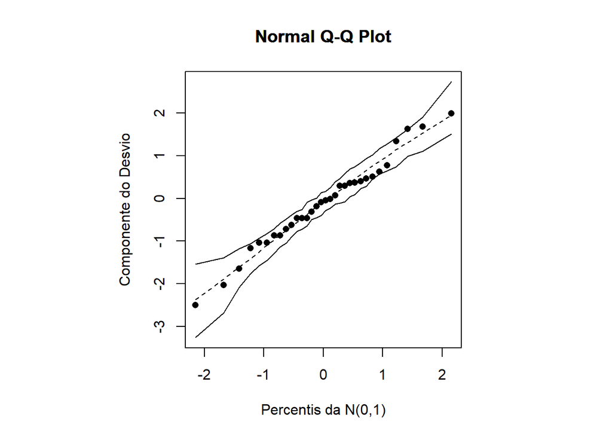

```
[1] "Gamma-Link(log)"
```

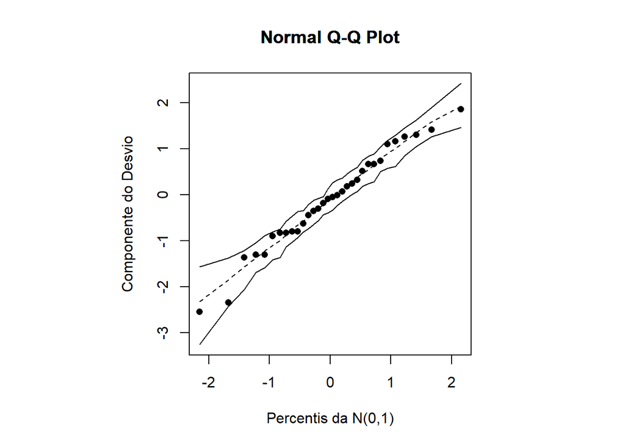

```
[1] "Gamma-Link(inverse)"
```

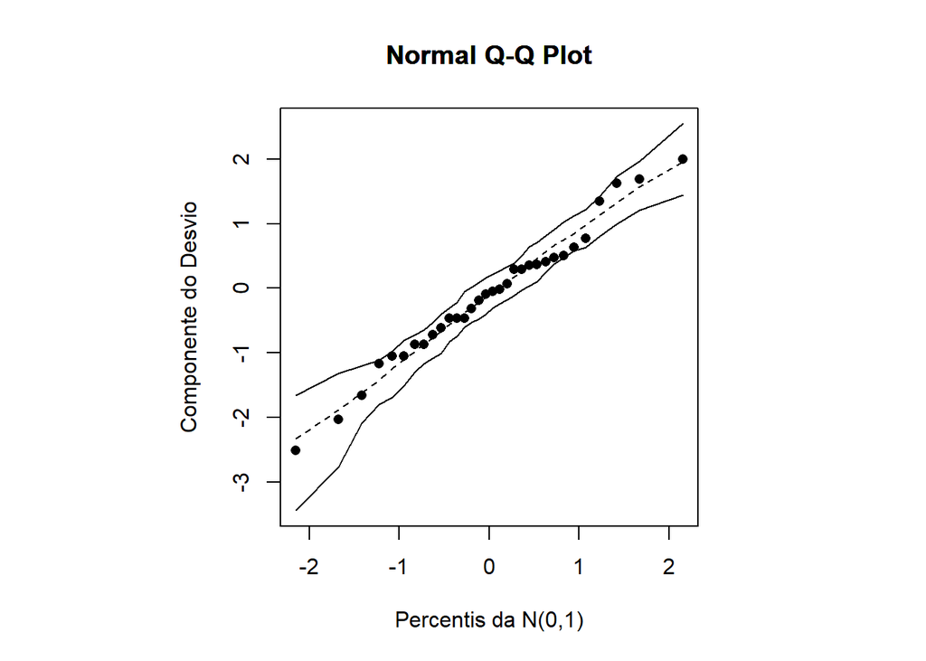

```r
selecaoModeloGama<-function(dados, modelo, ligacao)
{
  fit1<- try(switch(ligacao,
                identity = glm(modelo, family=Gamma),
                log = glm(modelo, family=Gamma(link=log)),
                inverse = glm(modelo, family=Gamma(link=inverse)),
                stop("Link não reconhecido")),silent = T)
  aux<-sum(class(fit1) != "try-error")
  if(aux==0)
  {
    fit.model<-0
  }else{
      fit.model<-stepAIC(fit1, trace=0)
  }
  return(fit.model)
}


ResultadosGama<-function(dados, modelo, ligacao, tipo, alfa=0.05)
{
  n<-nrow(dados)
  familia<-paste0("Gamma-Link(",ligacao,")")
  print(familia)
  fits<-selecaoModeloGama(dados, modelo, ligacao)
  if(is.numeric(fits))
  {
    bic<-"Não Rodou"
    qualidade<-"Não Rodou"
    modelo.s<-"-----"

  }else{
         bic<-as.numeric(round(AIC(fits,k=log(n)),6))
         modelo.s<-deparse(formula(fits))
         teste<-try(envelope(fits,tipo), silent=T)
         aux<-sum(class(teste) != "try-error")
         if(aux==0)
        {
           qualidade<-"Não Rodou"
        }else{
              qualidade<-teste[[1]]
          }
       }
 return(data.frame(Family=familia,
                      QQplot=qualidade,
                      BIC=bic,
                      Modelo=modelo.s))
}
gama<-rbind(
ResultadosGama(vidros, modelo, ligacao = "identity", tipo ="envel_gama"),
ResultadosGama(vidros, modelo, ligacao = "log", tipo ="envel_gama_log"),
ResultadosGama(vidros, modelo, ligacao = "inverse", tipo ="envel_gama_inverse"))
```

### Normal Inversa

**Código**

```
[1] "Normal Inversa-Link(identity)"
```

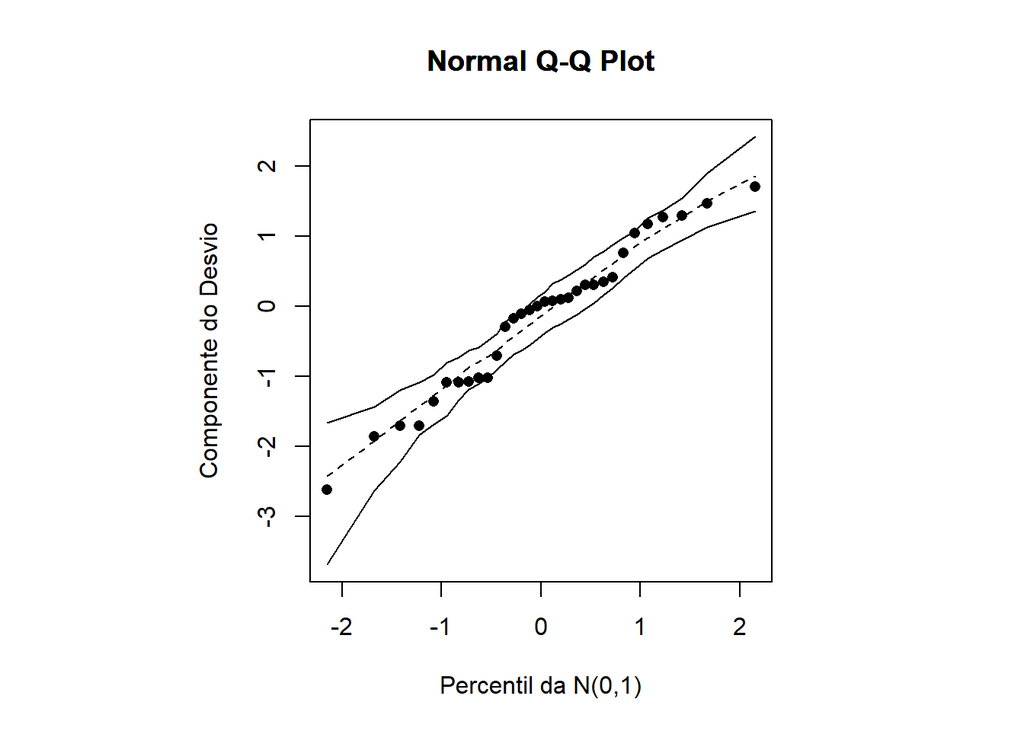

```
[1] "Normal Inversa-Link(log)"
```

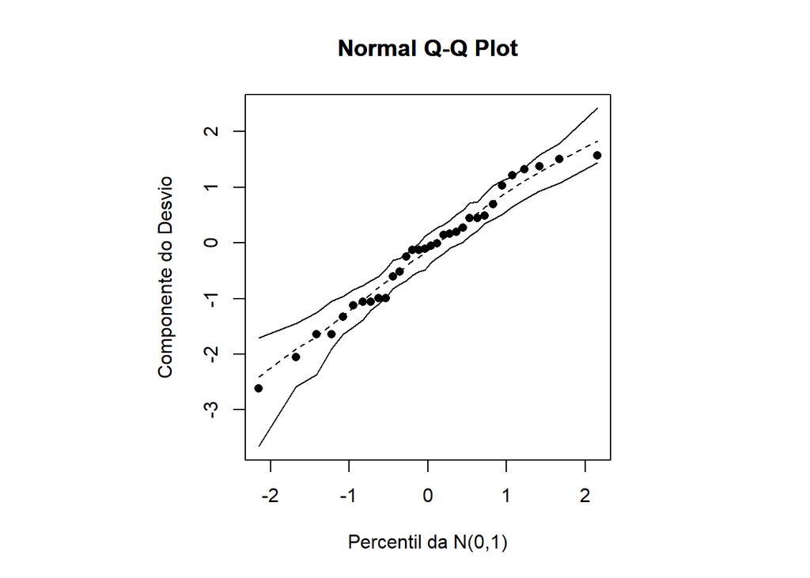

```
[1] "Normal Inversa-Link(inverse)"
```

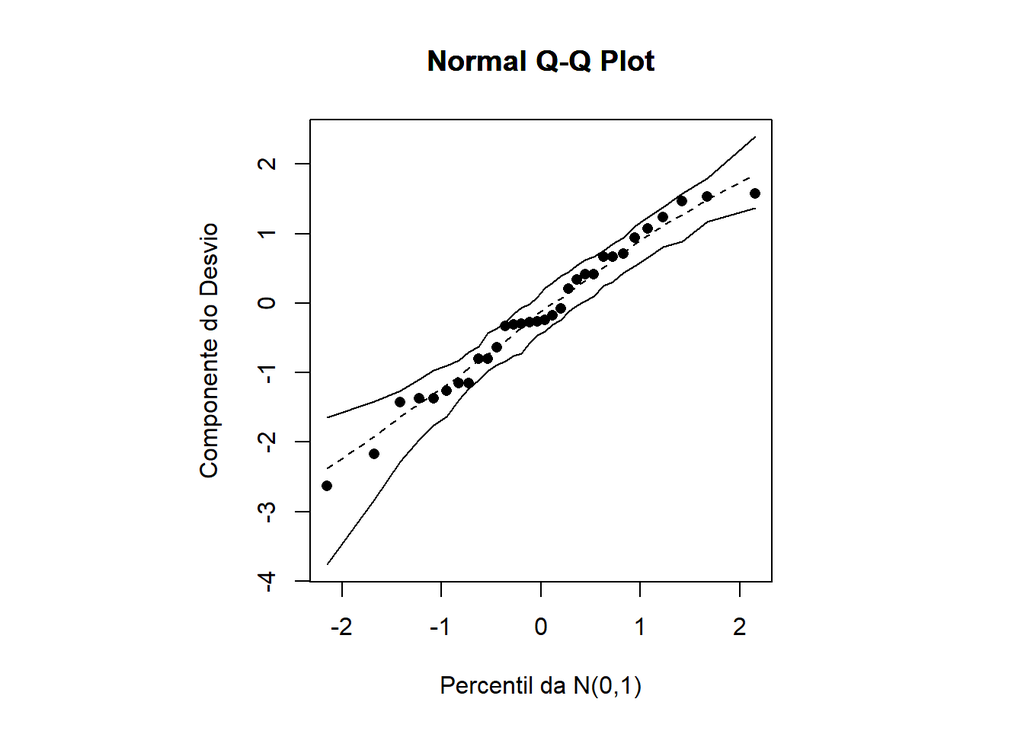

```
[1] "Normal Inversa-Link(inverse2)"
```

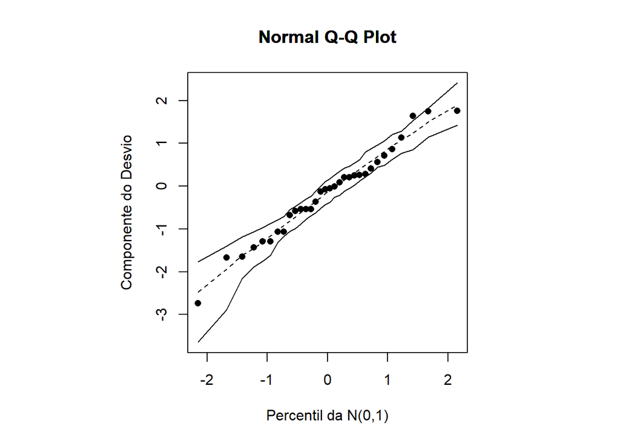

```r
selecaoNI<-function(dados, modelo, ligacao)
{
  fit1<- try(switch(ligacao,
                inverse2 = glm(modelo, family=inverse.gaussian),
                log = glm(modelo, family=inverse.gaussian(link=log)),
                inverse = glm(modelo, family=inverse.gaussian(link=inverse)),
                identity= glm(modelo, family=inverse.gaussian(link=identity)),
                stop("Link não reconhecido")), silent = T)
  aux<-sum(class(fit1) != "try-error")
  if(aux==0)
  {
    fit.model<-0
  }else{
    fit.model<-stepAIC(fit1, trace=0)
  }
  return(fit.model)

}



ResultadosNI<-function(dados, modelo, ligacao, tipo, alfa=0.05)
{
  n<-nrow(dados)
  familia<-paste0("Normal Inversa-Link(",ligacao,")")
  print(familia)
  fits<-selecaoNI(dados, modelo, ligacao)
  if(is.numeric(fits))
  {
    bic<-"Não Rodou"
    qualidade<-"Não Rodou"
    modelo.s<-"-----"
  }else{
    bic<-as.numeric(round(AIC(fits,k=log(n)),6))
    modelo.s<-deparse(formula(fits))
    teste<-try(envelope(fits,tipo), silent=T)
    aux<-sum(class(teste) != "try-error")
    if(aux==0)
    {
      qualidade<-"Não Rodou"
    }else{
          qualidade<-teste[[1]]
    }

  }
  return(data.frame(Family=familia,
                      QQplot=qualidade,
                      BIC=bic,
                      Modelo=modelo.s))
}

NI<-rbind(
ResultadosNI(vidros, modelo, ligacao = "identity", tipo ="envel_ninv"),
ResultadosNI(vidros, modelo, ligacao = "log", tipo ="envel_ninv_log"),
ResultadosNI(vidros, modelo, ligacao = "inverse", tipo ="envel_ninv_inverse"),
ResultadosNI(vidros, modelo, ligacao = "inverse2", tipo ="envel_ninv_inverse2"))
```

**Código**

```r
selecaoModelo<-rbind(normal, gama, NI
)

selecaoModelo |>
  arrange(BIC) |>
  knitr::kable(caption = "Melhor modelo", format ="pipe")
```

Melhor modelo

| Family | QQplot | BIC | Modelo |
| --- | --- | --- | --- |
| Gamma-Link(log) | Ótimo | 437.5214 | resistencia ~ voltagem + temperatura |
| Gamma-Link(identity) | Razoável | 438.1482 | resistencia ~ voltagem |
| Gamma-Link(inverse) | Ótimo | 438.1482 | resistencia ~ voltagem |
| Normal Inversa-Link(log) | Ruim | 438.6944 | resistencia ~ voltagem + temperatura |
| Normal Inversa-Link(identity) | Razoável | 439.2753 | resistencia ~ voltagem + temperatura |
| Normal Inversa-Link(inverse2) | Razoável | 439.8517 | resistencia ~ voltagem |
| Normal Inversa-Link(inverse) | Ótimo | 440.1159 | resistencia ~ voltagem + temperatura |
| Normal-Link(log) | Não Rodou | 444.3982 | resistencia ~ voltagem |
| Normal-Link(inverse) | Ruim | 444.3982 | resistencia ~ voltagem |
| Normal-Link(identity) | Ruim | 445.3932 | resistencia ~ voltagem + temperatura |

O modelo selecionado foi o Gama-Link(log) resistencia ~ voltagem + temperatura

## Teste de adequação da função de ligação

**Código**

```r
modelo<- resistencia ~ voltagem + temperatura
fit.model <- glm(modelo , family=Gamma(link=log))
pl2 <- predict(fit.model)^2
fit.model2<-glm(update.formula(modelo,~ . + pl2), family=Gamma(link=log))
testef(fit.model,fit.model2) # fit.model(H0: pl2 não significativa) #H1: pl2 é significativa
```

```
$f
[1] 0.553191

$df1
[1] 1

$df2
[1] 26

$pvalue
[1] 0.4636857
```

Não temos evidências para rejeitar $H_0$, a função de ligação “log” é adequada para o modelo.

## Resíduos e Diagnóstico

**Código**

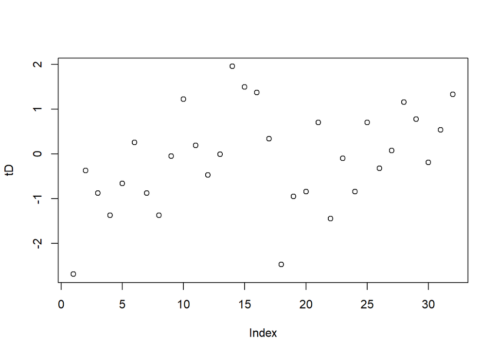

```r
modelo<- resistencia ~ voltagem + temperatura
fit.model <- glm(modelo , family=Gamma(link=log))
fi <- gamma.shape(fit.model)$alpha
X <- model.matrix(fit.model)
V <- fitted(fit.model)  # vetor de valores ajustados (model$fitted.values)
w <- fit.model$weights  # vetor de pesos
W <- diag(w)
H1 <- solve(t(X)%*%W%*%X)
H <- sqrt(W)%*%X%*%H1%*%t(X)%*%sqrt(W)
hii <- diag(H)  # vetor diagonal de H

# Residuos
rD <- resid(fit.model, type= "deviance")
tD <- rD*sqrt(fi/(1-hii))   # residuo deviance padronizado
rp1 <- resid(fit.model, type= "pearson")
rP <- as.numeric(sqrt(fi)*rp1)
tS <- rP/sqrt(V*(1 - hii))  # Residuo padronizado

plot(tD)
```

**Código**

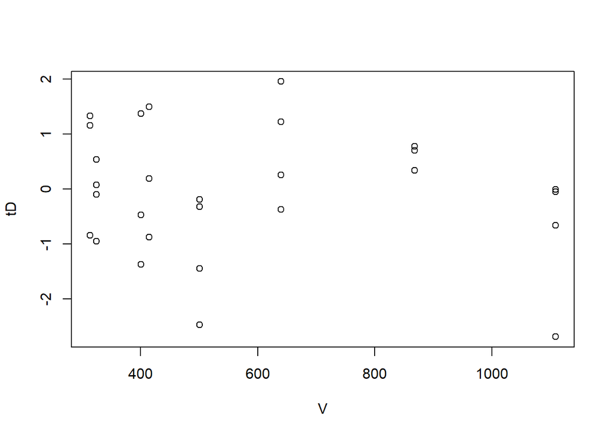

```r
plot(V,tD)
```

Não foi identificado nenhum padrão nos resíduos. O modelo foi validado.

#### Influência

**Código**

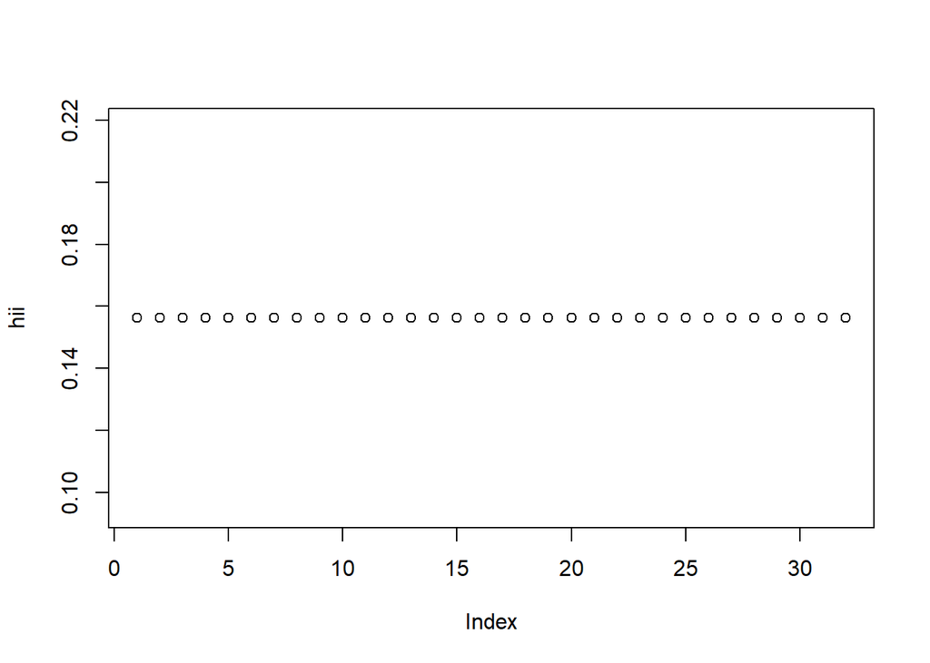

```r
plot(hii)
```

**Código**

```r
w
```

```
 1  2  3  4  5  6  7  8  9 10 11 12 13 14 15 16 17 18 19 20 21 22 23 24 25 26
 1  1  1  1  1  1  1  1  1  1  1  1  1  1  1  1  1  1  1  1  1  1  1  1  1  1
27 28 29 30 31 32
 1  1  1  1  1  1
```

Os peso $w_i$ são iguais a 1.

**Código**

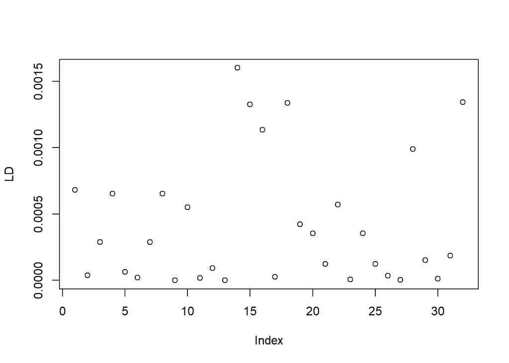

```r
LD = hii*(tS^2)/(1-hii)
plot(LD)
```

**Código**

```r
which(LD==max(LD))
```

```
14
14
```

**Código**

```r
X[14,]
```

```
     (Intercept)    voltagem250kV    voltagem300kV    voltagem350kV
               1                1                0                0
temperatura180°C
               0
```

**Código**

```r
voltagem[14]
```

```
[1] 250kV
Levels: 200kV 250kV 300kV 350kV
```

**Código**

```r
resistencia[14]
```

```
[1] 1090
```

**Código**

```r
summary(resistencia)
```

```
   Min. 1st Qu.  Median    Mean 3rd Qu.    Max.
  216.0   315.0   447.0   569.3   904.0  1105.0
```

## Interpretação

**Código**

```r
exp(fit.model$coefficients)
```

```
     (Intercept)    voltagem250kV    voltagem300kV    voltagem350kV
    1108.9209574        0.5769899        0.3737671        0.3610034
temperatura180°C
       0.7832847
```

A temperatura de 180°C reduz a resistência em 21.7% em relação a temperatura de 170°C.

A voltagem 250kV reduz a resistência em 42.3% comparado com a voltagem de 200kV.

A voltagem 300kV reduz a resistência em 62.6% comparado com a voltagem de 200kV.

A voltagem 350kV reduz a resistência em 63.9% comparado com a voltagem de 200kV.

# Exercício 15

**Código**

```r
suppressMessages(energy <- read_table("dados/lista2/energy.txt",
    col_names = FALSE))
colnames(energy)<-c("demanda","consumo_mensal")
```

## Análise Exploratória

**Código**

```r
suppressMessages(attach(energy))
summary(demanda)
```

```
   Min. 1st Qu.  Median    Mean 3rd Qu.    Max.
    292     679    1029    1153    1543    3560
```

**Código**

```r
summary(consumo_mensal)
```

```
   Min. 1st Qu.  Median    Mean 3rd Qu.    Max.
  0.170   0.790   3.250   3.413   4.880  14.940
```

**Código**

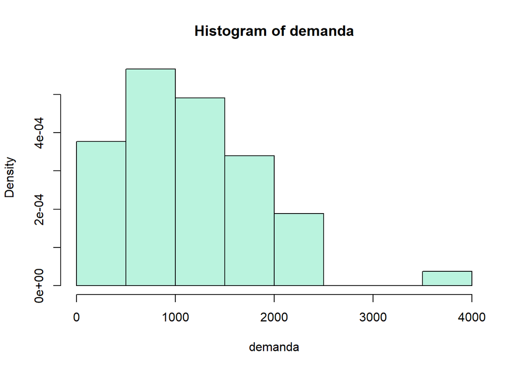

```r
hist(demanda, col=cores[1], freq=F)
```

A demanda é assimétrica positiva.

**Código**

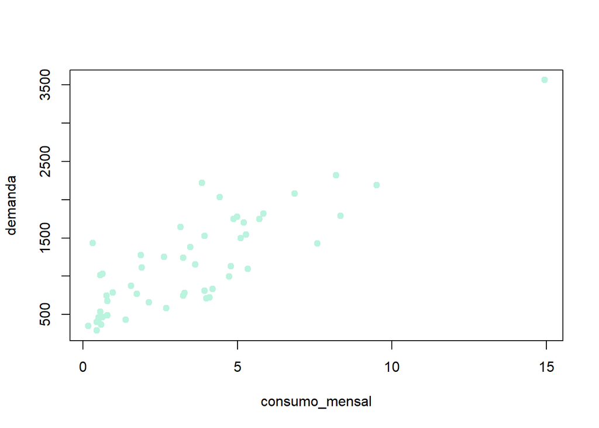

```r
plot(demanda~consumo_mensal, pch=19, col=cores[1])
```

## Seleção do modelo

### Normal

**Código**

```
[1] "Normal-Link(identity)"
```

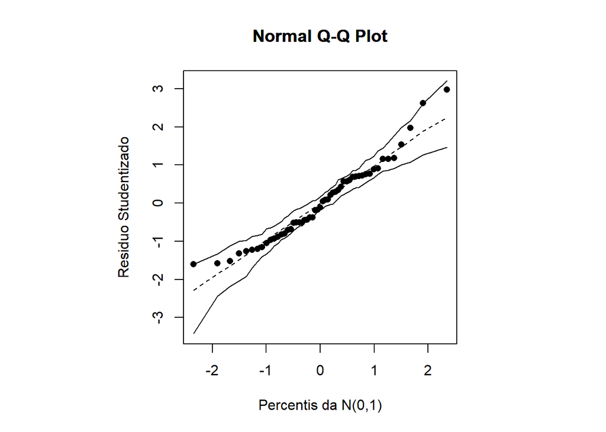

```
[1] "Normal-Link(log)"
[1] "Normal-Link(inverse)"
```

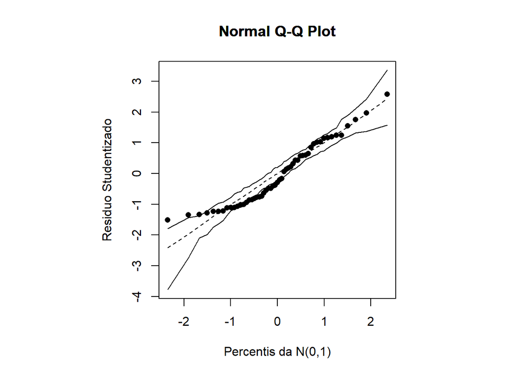

```r
modelo<-demanda ~ consumo_mensal
normal<-rbind(
ResultadosNormal(energy, modelo, ligacao = "identity", tipo ="envel_norm"),
ResultadosNormal(energy, modelo, ligacao = "log", tipo ="envel_norm_log"),
ResultadosNormal(energy, modelo, ligacao = "inverse", tipo ="envel_norm_inverse"))
```

### Gama

**Código**

```
[1] "Gamma-Link(identity)"
```

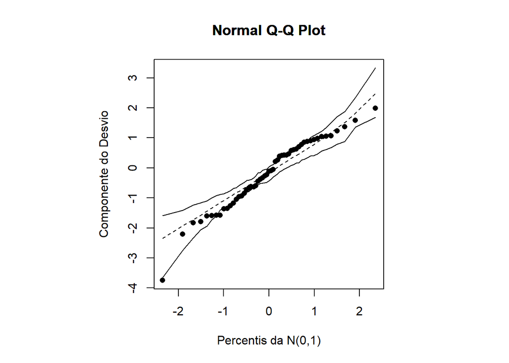

```
[1] "Gamma-Link(log)"
```

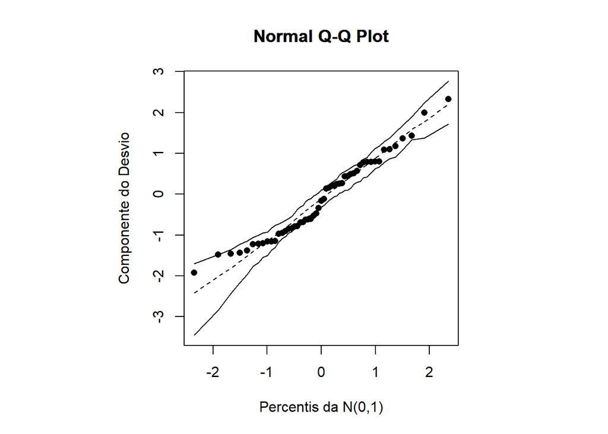

```
[1] "Gamma-Link(inverse)"
```

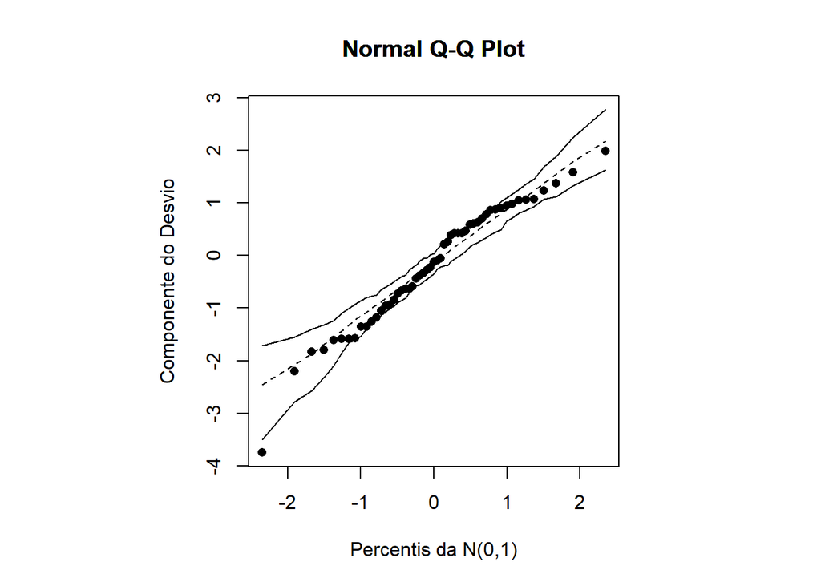

```r
gama<-rbind(
ResultadosGama(energy, modelo, ligacao = "identity", tipo ="envel_gama"),
ResultadosGama(energy, modelo, ligacao = "log", tipo ="envel_gama_log"),
ResultadosGama(energy, modelo, ligacao = "inverse", tipo ="envel_gama_inverse"))
```

### Normal Inversa

**Código**

```
[1] "Normal Inversa-Link(identity)"
```

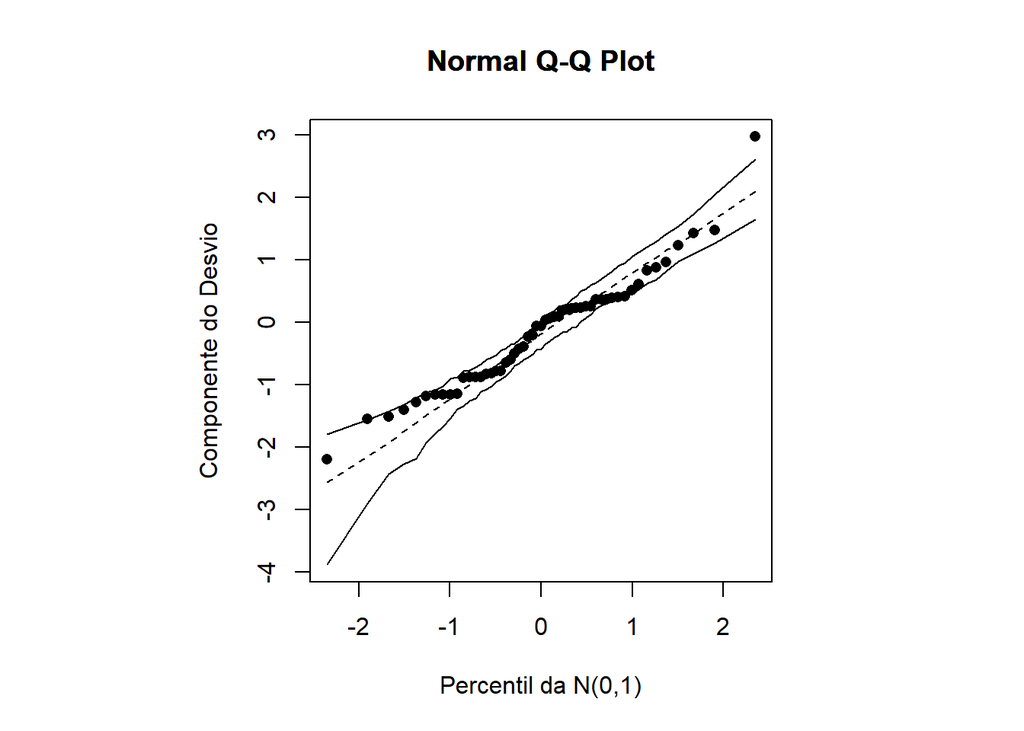

```
[1] "Normal Inversa-Link(log)"
```

```
[1] "Normal Inversa-Link(inverse)"
```

```
[1] "Normal Inversa-Link(inverse2)"
```

```r
NI<-rbind(
ResultadosNI(energy, modelo, ligacao = "identity", tipo ="envel_ninv"),
ResultadosNI(energy, modelo, ligacao = "log", tipo ="envel_ninv_log"),
ResultadosNI(energy, modelo, ligacao = "inverse", tipo ="envel_ninv_inverse"),
ResultadosNI(energy, modelo, ligacao = "inverse2", tipo ="envel_ninv_inverse2"))
```

**Código**

```r
selecaoModelo<-rbind(normal, gama, NI
)

selecaoModelo |>
  arrange(BIC) |>
  knitr::kable(caption = "Melhor modelo", format ="pipe")
```

Melhor modelo

| Family | QQplot | BIC | Modelo |
| --- | --- | --- | --- |
| Normal-Link(identity) | Ruim | 784.055093 | demanda ~ consumo_mensal |
| Gamma-Link(log) | Ruim | 789.215998 | demanda ~ consumo_mensal |
| Normal-Link(log) | Não Rodou | 792.046266 | demanda ~ consumo_mensal |
| Normal Inversa-Link(identity) | Ruim | 795.000052 | demanda ~ consumo_mensal |
| Normal Inversa-Link(log) | Não Rodou | 796.958915 | demanda ~ consumo_mensal |
| Gamma-Link(identity) | Ruim | 804.370421 | demanda ~ consumo_mensal |
| Gamma-Link(inverse) | Ruim | 804.370421 | demanda ~ consumo_mensal |
| Normal-Link(inverse) | Ruim | 806.387261 | demanda ~ consumo_mensal |
| Normal Inversa-Link(inverse) | Não Rodou | Não Rodou | —– |
| Normal Inversa-Link(inverse2) | Não Rodou | Não Rodou | —– |

O modelo selecionado foi o Normal Inversa - Link (log) demanda ~ consumo_mensal

## Teste de adequação da função de ligação

**Código**

```r
modelo<- demanda ~ consumo_mensal
fit.model <- glm(modelo , family=inverse.gaussian(link=log))
pl2 <- predict(fit.model)^2
fit.model2<-glm(update.formula(modelo,~ . + pl2), family=inverse.gaussian(link=log))
testef(fit.model,fit.model2) # fit.model(H0: pl2 não significativa) #H1: pl2 é significativa
```

```
$f
[1] 1.661681

$df1
[1] 1

$df2
[1] 50

$pvalue
[1] 0.2033085
```

A ligação log é adequada para o modelo.

## Resíduos e Diagnóstico

**Código**

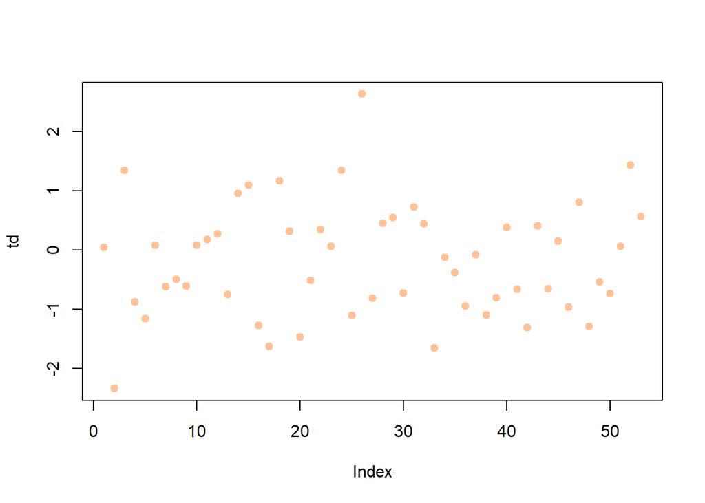

```r
modelo<-demanda ~ consumo_mensal
fit.model<-glm(modelo,family=inverse.gaussian(link=log))
X <- model.matrix(fit.model)
n <- nrow(X)
p <- ncol(X)
w <- fit.model$weights
V<-fitted(fit.model)
mu <-predict(fit.model,type="response")
W <- diag(w)
H <- solve(t(X)%*%W%*%X)
H <- sqrt(W)%*%X%*%H%*%t(X)%*%sqrt(W)
hii <- diag(H)
ro <- resid(fit.model,type="response")
fi <- (n-p)/sum((ro^2)/(fitted(fit.model)^3))
td <- resid(fit.model,type="deviance")*sqrt(fi/(1-hii))
# residuo deviance padronizado
rp1 <- resid(fit.model, type= "pearson")
rP <- as.numeric(sqrt(fi)*rp1)
tS <- rP/sqrt(V*(1 - hii))  # Residuo padronizado
plot(td,pch=19, col=cores[3])
```

**Código**

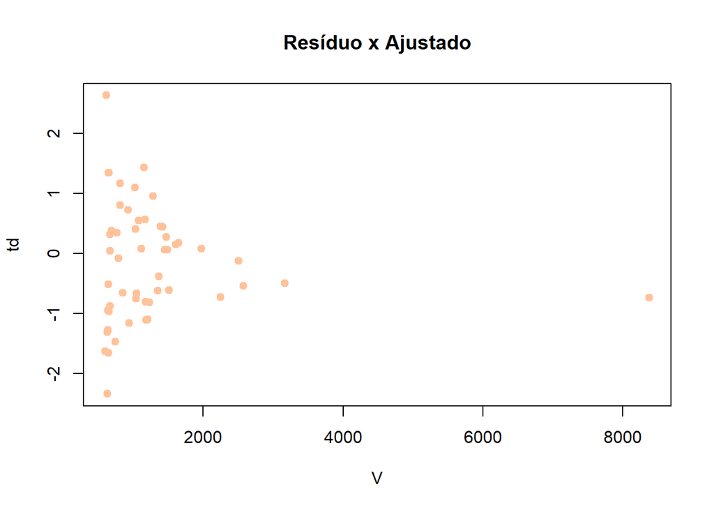

```r
plot(V,td, main="Resíduo x Ajustado", pch=19, col=cores[3])
```

**Código**

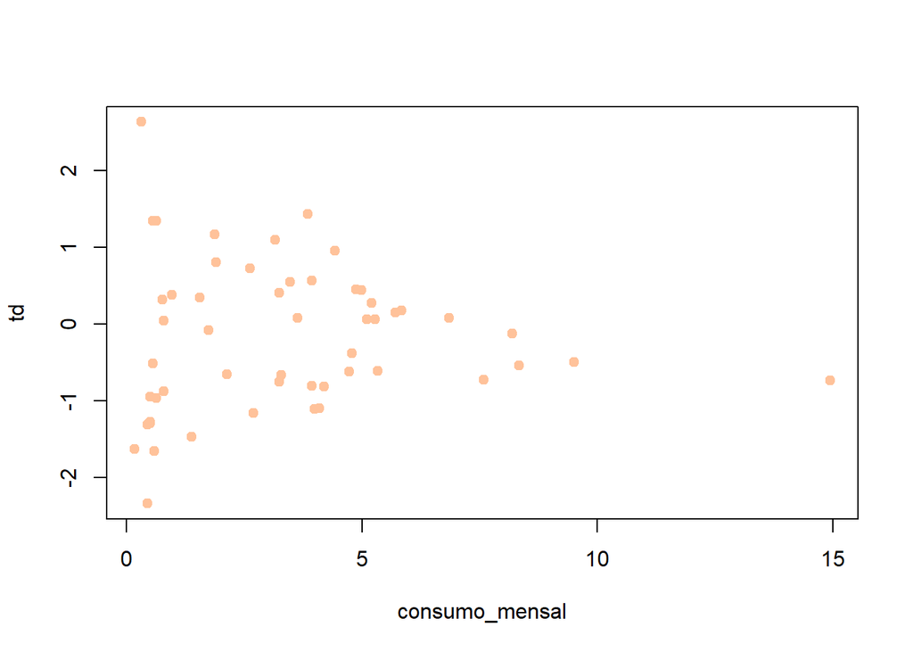

```r
plot(consumo_mensal, td,pch=19, col=cores[3] )
```

**Código**

```r
str(td)
```

```
 Named num [1:53] 0.0419 -2.3376 1.3475 -0.8795 -1.1604 ...
 - attr(*, "names")= chr [1:53] "1" "2" "3" "4" ...
```

Os resíduos não parecem homocedásticos, a variância diminui com o aumento do valor predito.

#### Influência

**Código**

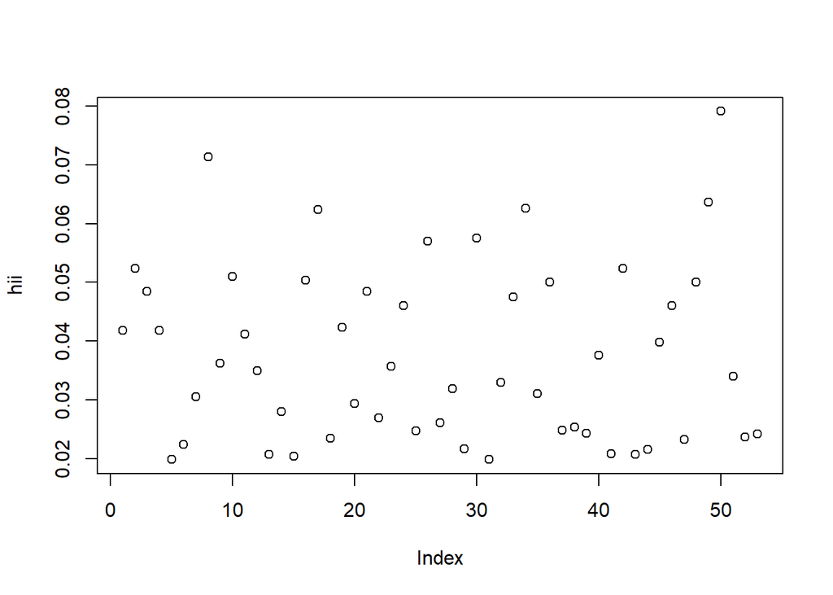

```r
plot(hii)
```

**Código**

```r
hii[50]
```

```
[1] 0.0791163
```

**Código**

```r
consumo_mensal[50]
```

```
[1] 14.94
```

**Código**

```r
demanda[50]
```

```
[1] 3560
```

**Código**

```r
summary(demanda)
```

```
   Min. 1st Qu.  Median    Mean 3rd Qu.    Max.
    292     679    1029    1153    1543    3560
```

**Código**

```r
summary(consumo_mensal)
```

```
   Min. 1st Qu.  Median    Mean 3rd Qu.    Max.
  0.170   0.790   3.250   3.413   4.880  14.940
```

A observação 50 é a com maior alavanca, ela é o domicílio com maior consumo e maior demanda em horário de pico.

**Código**

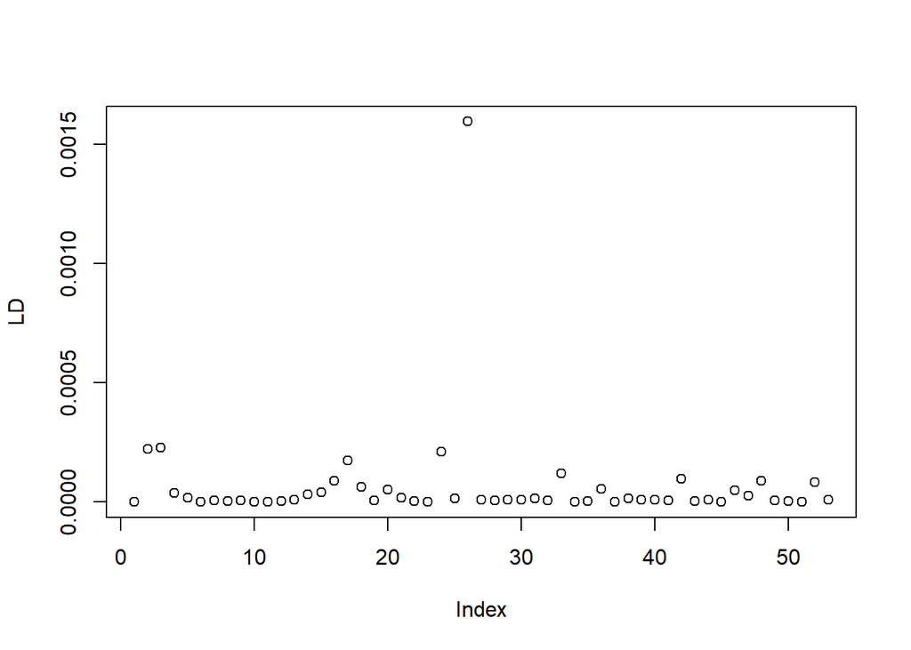

```r
LD = hii*(tS^2)/(1-hii)
plot(LD)
```

**Código**

```r
which(LD==max(LD))
```

```
26
26
```

A observação 26 exerce maior influência na verossimilhança.

**Código**

```r
X[26,]
```

```
   (Intercept) consumo_mensal
          1.00           0.31
```

**Código**

```r
summary(consumo_mensal)
```

```
   Min. 1st Qu.  Median    Mean 3rd Qu.    Max.
  0.170   0.790   3.250   3.413   4.880  14.940
```

**Código**

```r
demanda[26]
```

```
[1] 1434
```

**Código**

```r
summary(demanda)
```

```
   Min. 1st Qu.  Median    Mean 3rd Qu.    Max.
    292     679    1029    1153    1543    3560
```

Esse domicílio apresenta uma demanda acima da média no horário de pico com um consumo mensal abaixo da média.

## Interpretação

**Código**

```r
exp(fit.model$coefficients)
```

```
   (Intercept) consumo_mensal
    581.080888       1.195563
```

- A cada unidade de consumo mensal que aumenta a demanda do domicílio em horário de pico aumenta em 19.55%.

# Exercício 16

**Código**

```r
suppressMessages(restaurante <- read_table("dados/lista2/restaurante.txt",
    col_names = FALSE))
colnames(restaurante)<-c("faturamento","gasto")
```

## Análise Exploratória

**Código**

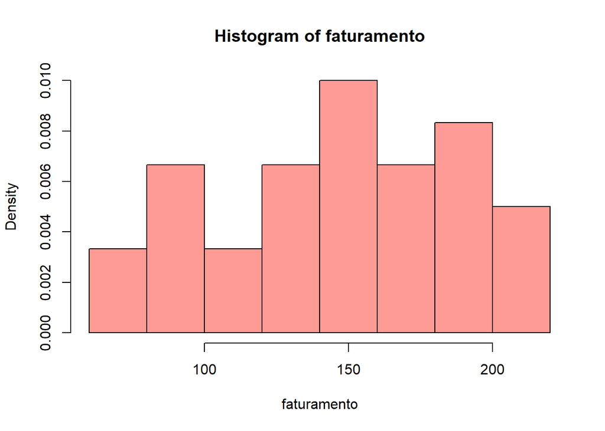

```r
suppressMessages(attach(restaurante))
hist(faturamento, col=cores[4], freq = F, breaks = 10)
```

**Código**

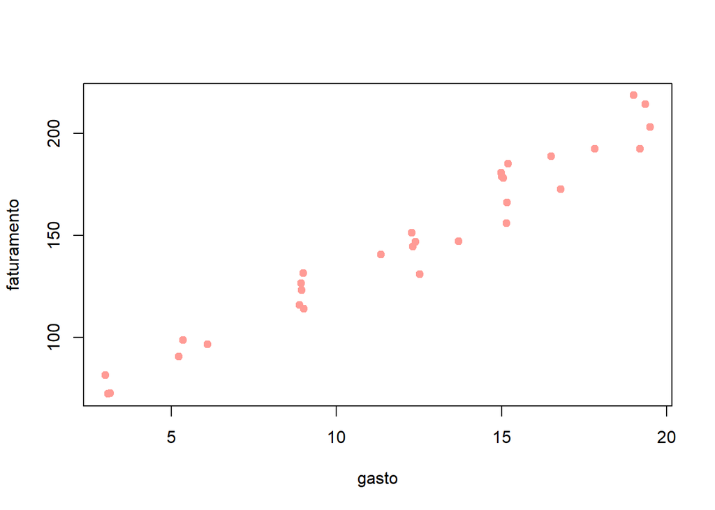

```r
plot(faturamento~gasto, pch=19, col=cores[4])
```